[figure not shown]

## Análisis de la Plataforma de Atención al Ciudadano de la Municipalidad de Santa Anita

#### Elaborado por el Laboratorio de Políticas Públicas de la PUCP

La Plataforma de Atención al Ciudadano de la Municipalidad de Santa Anita es un espacio, ofrecido a los vecinos de dicho distrito, para la realización de tramites, acceso a información, recepción de quejas, entre otros. A través de este servicio, la Municipalidad ha buscado simplificar los tramites, personalizar la atención y minimizar el tiempo de espera del ciudadano.

El siguiente ejercicio tuvo como objetivo evaluar la eficacia de los servicios brindados a los ciudadanos a través de la Plataforma, mediante un análisis del desempeño de las ventanillas de atención. El énfasis se encuentra en el tiempo de espera del ciudadano.

En total, se analizaron **53 972 atenciones** registradas entre los meses de enero y junio del 2018.

#### Atenciones al ciudadano por día

El siguiente gráfico permite analizar los niveles de concurrencia de los ciudadanos a la Plataforma, según los días de la semana y horarios de atención.

- El día lunes concentra el mayor número de atenciones. En promedio, cada lunes se atienden a 464 ciudadanos.
- El mayor flujo de ciudadanos se encuentra entre las 9 am y 12 pm. En promedio, se realizan 118 atenciones durante dicho horario cada día.

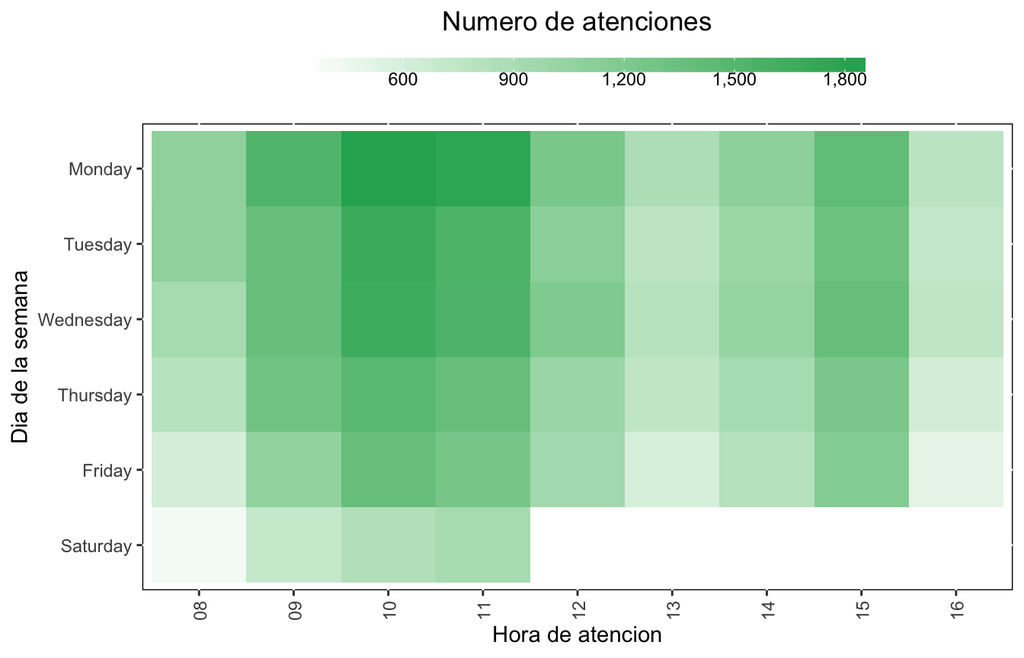

#### Atenciones al ciudadano por ventanilla

En total, existen **17 ventanillas implementadas** en la Plataforma. Sin embargo, como se muestra en el siguiente gráfico, no todas las ventanillas han atendido durante la totalidad de días observados.

- Destaca que las **ventanillas 2 y 8** atendieron menos de 15 días durante la observación. Es decir, atendieron durante menos del 15% de días observados.

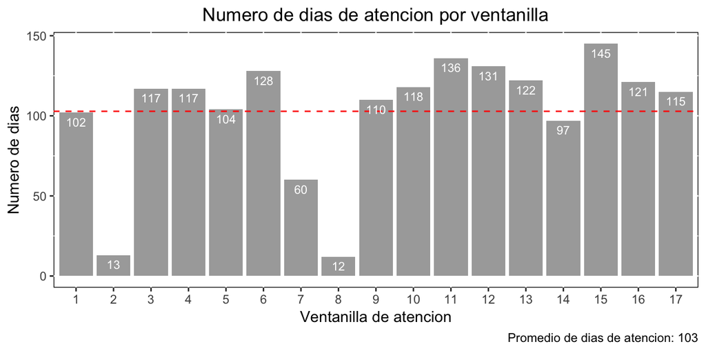

El siguiente gráfico muestra el promedio de ciudadanos atendidos por cada ventanilla durante la observación.

- En promedio, cada ventanilla ha atendido a **3 175 ciudadanos** durante la observación.
- Las **ventanillas 1,3,16 y 17** han atendido a un número de ciudadanos por debajo del promedio general.

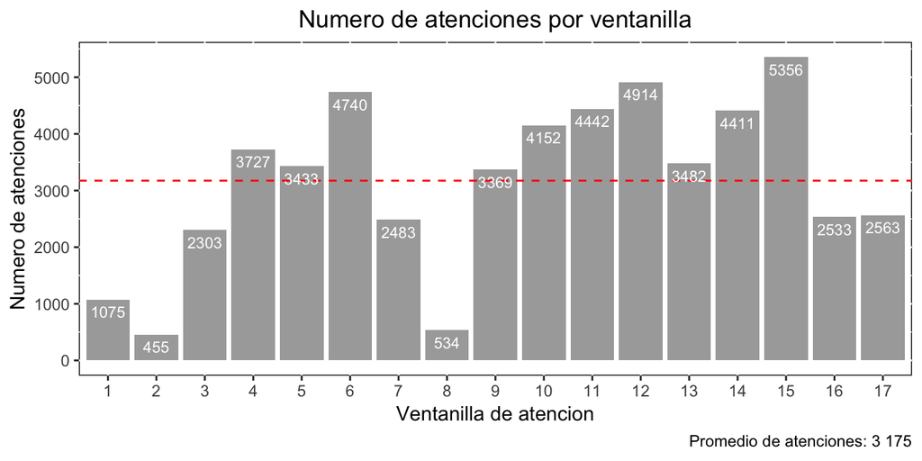

#### Tiempo promedio de atención por ventanilla

En promedio, desde que el ciudadano llega a la Municipalidad hasta el momento en que se retira tras ser atendido pasan **24.6 minutos**. Sin embargo, de dicho total, son solo 8.3 minutos los que conforman el tiempo de atención, y 16.3 minutos el tiempo de espera. Esto tiene impactos significativos en la calidad de atención ofrecida a los usuarios, quienes pasan, en promedio, **dos tercios del tiempo esperando a ser atendidos.**

El siguiente gráfico muestra el tiempo promedio de atención por ventanilla. Como se observa, existe un alto nivel de dispersión en los tiempos de atención ofrecidos en las ventanillas.

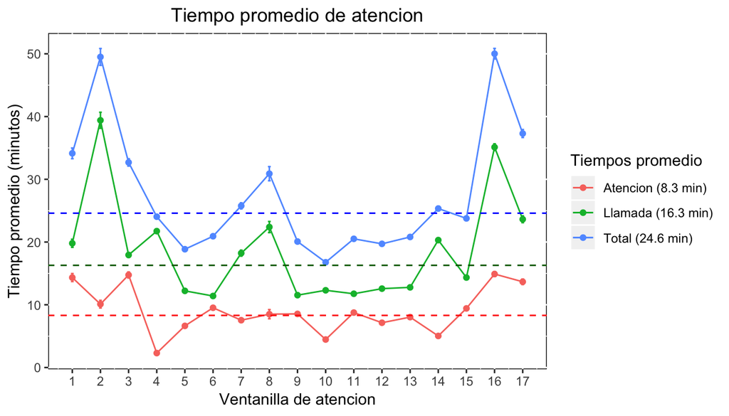

#### Tipo de espera del ciudadano por ventanilla

El tiempo del ciudadano en la Plataforma se divide entre el tiempo de espera para ser atendido y la duración de la realización del tramite. El siguiente gráfico muestra el porcentaje que representa cada tipo de espera en la Plataforma por ventanilla.

- Las **ventanillas 4 y 14** destacan puesto que, de todo el tiempo de espera del ciudadano en la Plataforma, menos del 20% representa la realización del tramite. El resto del tiempo del ciudadano representa la espera para ser atendido.

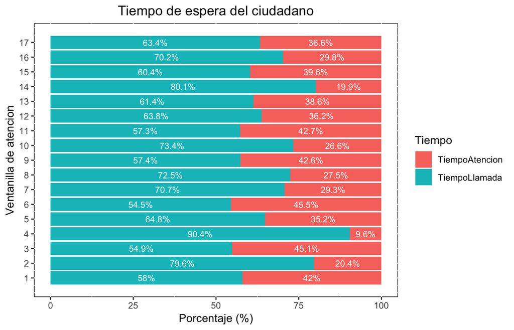

#### Atenciones al ciudadano por tipo de tramite

El siguiente gráfico muestra el número de atenciones por tipo de tramite, durante el periodo de observación.

- Cerca del 50% de atenciones corresponden a consultas de Estado de Cuenta.

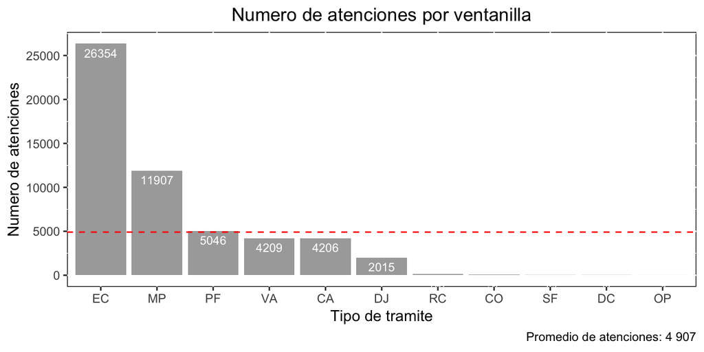

#### Tipo de espera del ciudadano por tipo de tramite

El siguiente gráfico muestra el porcentaje que representa cada tipo de espera en la Plataforma por tipo de tramite.

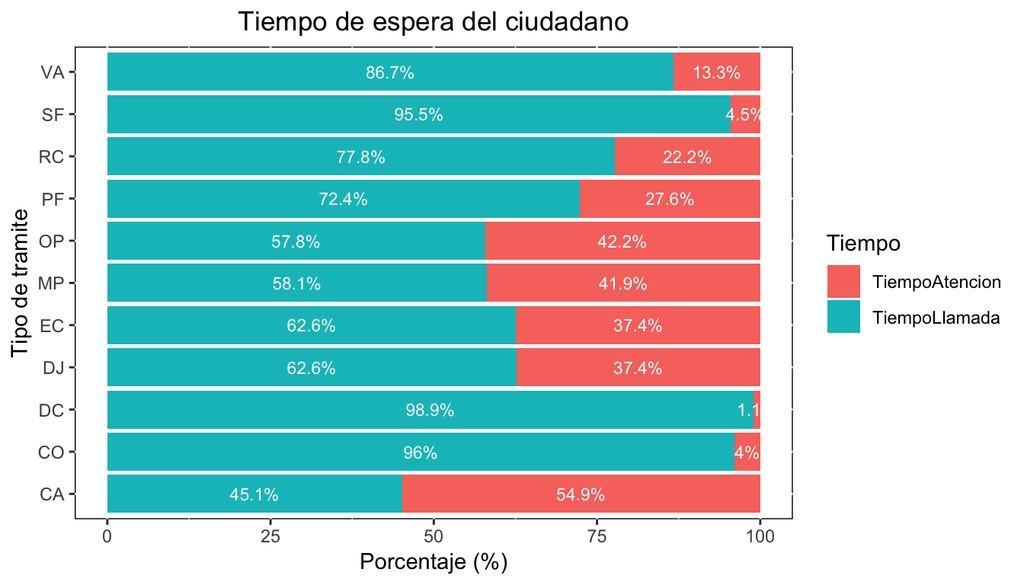

**El equipo del LabPUCP está conformado por:**

Director: Dr. José Manuel Magallanes.

Investigadora Senior:

- Lic. María Gracia Becerra.

Investigadores Junior:

- Alexander Benites.
- María Alejandra Gutierrez.